# Métodos no supervisados

Brando Aucancela

11/14/2021

# Ejercicio 1

Presenta el juego de datos, nombre y significado de cada columna, así como las distribuciones de sus valores. Adicionalmente realiza un estudio similar al de los ejemplos 1.1 y 1.2

## Método de agregación k-means con datos reales

Debido a que se tiene datos reales solo se incluyó ciertas partes del punto 1.1

Librerías

```r
if(!require('Stat2Data'))install.packages('Stat2Data')
library(Stat2Data)
if(!require('cluster'))install.packages('cluster')
library(cluster)
if(!require('fpc'))install.packages('fpc')
library(fpc)
```

Carga de Base de Datos Hawks

```r
data("Hawks")
summary(Hawks)
```

```
##      Month             Day             Year       CaptureTime   ReleaseTime
##  Min.   : 8.000   Min.   : 1.00   Min.   :1992   11:35  : 14          :842
##  1st Qu.: 9.000   1st Qu.: 9.00   1st Qu.:1995   13:30  : 14   11:00  :  2
##  Median :10.000   Median :16.00   Median :1999   11:45  : 13   11:35  :  2
##  Mean   : 9.843   Mean   :15.74   Mean   :1998   12:10  : 13   12:05  :  2
##  3rd Qu.:10.000   3rd Qu.:23.00   3rd Qu.:2001   14:00  : 13   12:50  :  2
##  Max.   :11.000   Max.   :31.00   Max.   :2003   13:05  : 12   13:32  :  2
##                                                  (Other):829   (Other): 56
##       BandNumber  Species  Age     Sex          Wing           Weight
##            :  2   CH: 70   A:224    :576   Min.   : 37.2   Min.   :  56.0
##  1142-09240:  1   RT:577   I:684   F:174   1st Qu.:202.0   1st Qu.: 185.0
##  1142-09241:  1   SS:261           M:158   Median :370.0   Median : 970.0
##  1142-09242:  1                            Mean   :315.6   Mean   : 772.1
##  1142-18229:  1                            3rd Qu.:390.0   3rd Qu.:1120.0
##  1142-19209:  1                            Max.   :480.0   Max.   :2030.0
##  (Other)   :901                            NA's   :1       NA's   :10
##      Culmen         Hallux            Tail        StandardTail
##  Min.   : 8.6   Min.   :  9.50   Min.   :119.0   Min.   :115.0
##  1st Qu.:12.8   1st Qu.: 15.10   1st Qu.:160.0   1st Qu.:162.0
##  Median :25.5   Median : 29.40   Median :214.0   Median :215.0
##  Mean   :21.8   Mean   : 26.41   Mean   :198.8   Mean   :199.2
##  3rd Qu.:27.3   3rd Qu.: 31.40   3rd Qu.:225.0   3rd Qu.:226.0
##  Max.   :39.2   Max.   :341.40   Max.   :288.0   Max.   :335.0
##  NA's   :7      NA's   :6                        NA's   :337
##      Tarsus        WingPitFat        KeelFat           Crop
##  Min.   :24.70   Min.   :0.0000   Min.   :0.000   Min.   :0.0000
##  1st Qu.:55.60   1st Qu.:0.0000   1st Qu.:2.000   1st Qu.:0.0000
##  Median :79.30   Median :1.0000   Median :2.000   Median :0.0000
##  Mean   :71.95   Mean   :0.7922   Mean   :2.184   Mean   :0.2345
##  3rd Qu.:87.00   3rd Qu.:1.0000   3rd Qu.:3.000   3rd Qu.:0.2500
##  Max.   :94.00   Max.   :3.0000   Max.   :4.000   Max.   :5.0000
##  NA's   :833     NA's   :831      NA's   :341     NA's   :343
```

Verificamos la estructura del juego de datos principal.

```r
str(Hawks)
```

```
## 'data.frame':    908 obs. of  19 variables:
##  $ Month       : int  9 9 9 9 9 9 9 9 9 9 ...
##  $ Day         : int  19 22 23 23 27 28 28 29 29 30 ...
##  $ Year        : int  1992 1992 1992 1992 1992 1992 1992 1992 1992 1992 ...
##  $ CaptureTime : Factor w/ 308 levels " ","1:15","1:31",..: 181 25 138 42 62 71 181 88 261 192 ...
##  $ ReleaseTime : Factor w/ 60 levels ""," ","10:20",..: 1 2 2 2 2 2 2 2 2 2 ...
##  $ BandNumber  : Factor w/ 907 levels " ","1142-09240",..: 856 857 858 809 437 280 859 860 861 281 ...
##  $ Species     : Factor w/ 3 levels "CH","RT","SS": 2 2 2 1 3 2 2 2 2 2 ...
##  $ Age         : Factor w/ 2 levels "A","I": 2 2 2 2 2 2 2 1 1 2 ...
##  $ Sex         : Factor w/ 3 levels "","F","M": 1 1 1 2 2 1 1 1 1 1 ...
##  $ Wing        : num  385 376 381 265 205 412 370 375 412 405 ...
##  $ Weight      : int  920 930 990 470 170 1090 960 855 1210 1120 ...
##  $ Culmen      : num  25.7 NA 26.7 18.7 12.5 28.5 25.3 27.2 29.3 26 ...
##  $ Hallux      : num  30.1 NA 31.3 23.5 14.3 32.2 30.1 30 31.3 30.2 ...
##  $ Tail        : int  219 221 235 220 157 230 212 243 210 238 ...
##  $ StandardTail: int  NA NA NA NA NA NA NA NA NA NA ...
##  $ Tarsus      : num  NA NA NA NA NA NA NA NA NA NA ...
##  $ WingPitFat  : int  NA NA NA NA NA NA NA NA NA NA ...
##  $ KeelFat     : num  NA NA NA NA NA NA NA NA NA NA ...
##  $ Crop        : num  NA NA NA NA NA NA NA NA NA NA ...
```

**Month** Mes de la captura de specimen.

**Day** Día de la captura del specimen.

**Year** Año de la captura del specimen.

**CaptureTime** Hora de captura en formato (HH:MM).

**ReleaseTime** Hora de lanzamiento en formato (HH:MM).

**BandNumber** Código de banda de identificación.

**Species** Es pecie a la que pertencie: CH= Cooper’s, RT= Red-tailed, SS= Sharp-Shinned.

**Age** Edad cualitativa: A=Adulto o I=Imaduro.

**Sex** F=Mujer o M=Hombre.

**Wing** Longitud (mm) de la pluma del ala primaria, desde la punta hasta la muñeca a la que se adhiere.

**Weight** Peso corporal (gr).

**Culmen** Longitud (mm) del pico superior, desde la punta hasta donde choca con la parte carnosa del ave.

**Hallux** Longitud (mm) de la garra asesina.

**Tail** Medida (mm) relacionada con la longitud de la cola (inventada en el MacBride Raptor Center).

**StandardTail** Medida estándar de la longitud de la cola (mm).

**Tarsus** Longitud del hueso básico del pie (mm). StandardTail KeelFat Crop

**WingPitFat** Cantidad de grasa en el hoyo de las alas.

**KeelFat** Cantidad de grasa en el esternón (medida por tacto).

**Crop** Cantidad de material en el cultivo, codificado de1=lleno a 0=vacío.

La información fue obtenida de: https://vincentarelbundock.github.io/Rdatasets/doc/Stat2Data/Hawks.html

Verificación de columnas con valores nulos

```r
colSums(is.na(Hawks))
```

```
##        Month          Day         Year  CaptureTime  ReleaseTime   BandNumber
##            0            0            0            0            0            0
##      Species          Age          Sex         Wing       Weight       Culmen
##            0            0            0            1           10            7
##       Hallux         Tail StandardTail       Tarsus   WingPitFat      KeelFat
##            6            0          337          833          831          341
##         Crop
##          343
```

Debido a que algunas comunas poseen valores nulos eliminamos las que contengan más de 800 valores nulos.

```r
Hawks <- Hawks[ , !(names(Hawks) %in% c('Tarsus', 'WingPitFat'))]
```

Colocamos la media en StandardTail para que no se pierda muchos datos al momento de eliminar las filas que comtemgan valores nulos.

```r
Hawks$StandardTail[is.na(Hawks$StandardTail)] <- mean(Hawks$StandardTail,na.rm=T)
```

Al tener los nombre de lcaracteristicas (columnas) se consideraía como problema de clasifición supervisada, por lo que eliminamos la columna Species

```r
x_0 <- na.omit(Hawks[, c("Wing", "Weight", "Culmen", "Hallux", "Tail", "StandardTail")])
```

Normalizado de columnas

```r
#definición de la funcion Min-Max
min_max_norm <- function(x) {
    (x - min(x)) / (max(x) - min(x))
  }
```

```r
#aplicacion de MIn-Max al dataframe X
x <- as.data.frame(lapply(x_0, min_max_norm))
```

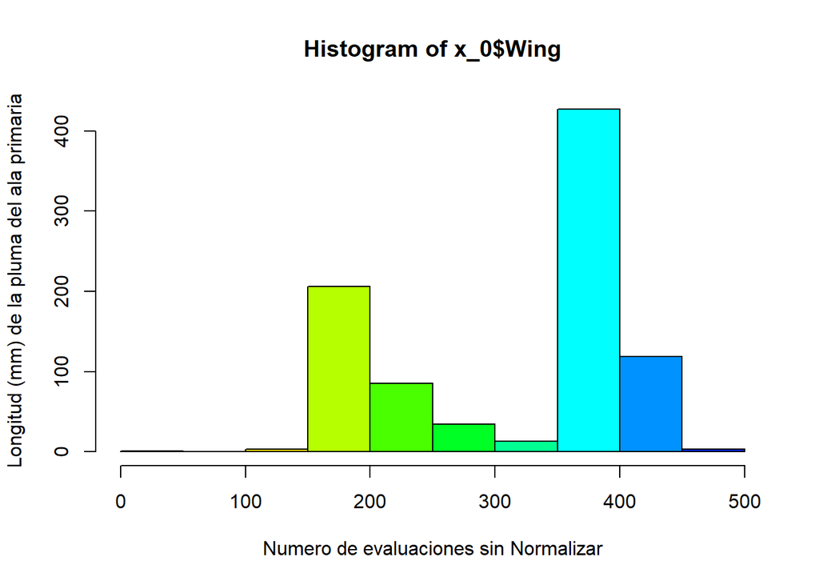

```r
hist(x_0$Wing,xlab="Numero de evaluaciones sin Normalizar", col=rainbow(14) ,ylab="Longitud (mm) de la pluma del ala primaria")
```

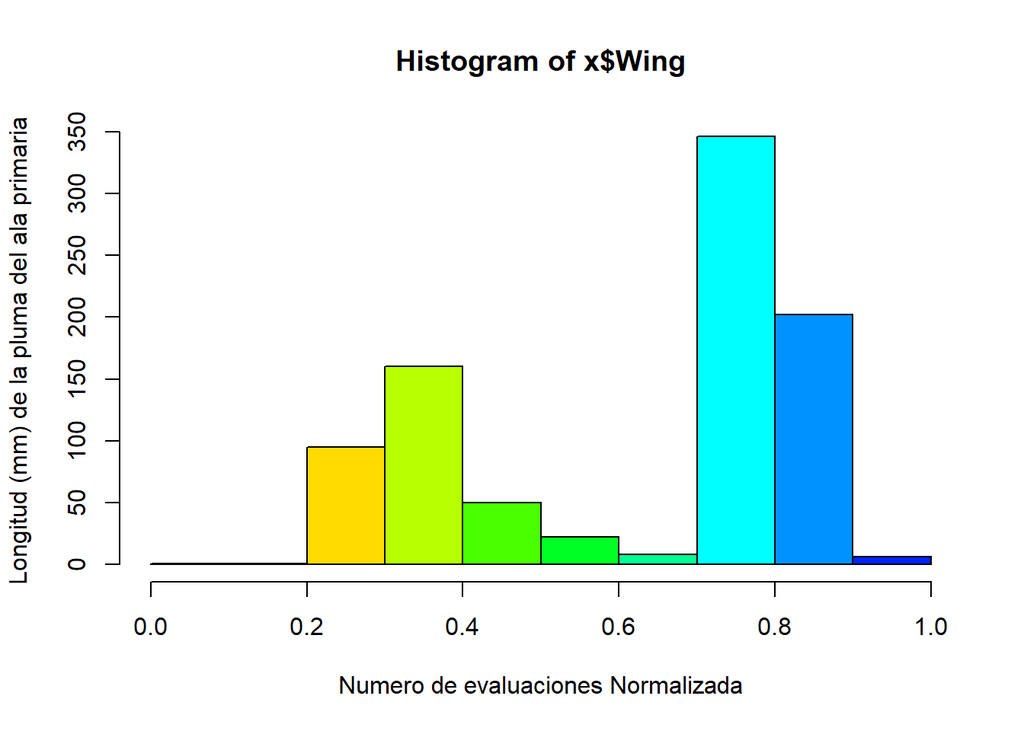

```r
hist(x$Wing,xlab="Numero de evaluaciones Normalizada", col=rainbow(14) ,ylab="Longitud (mm) de la pluma del ala primaria")
```

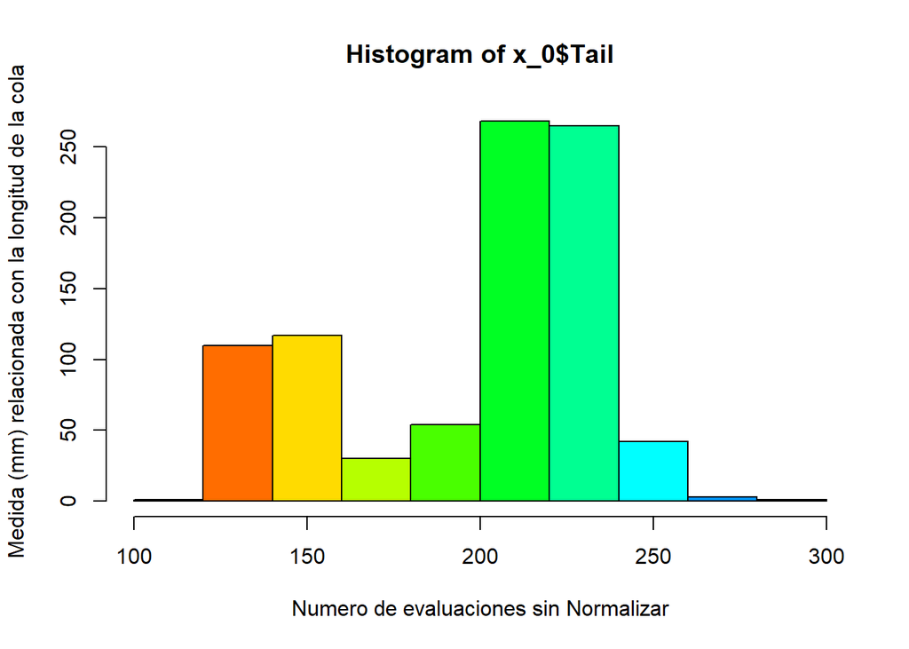

```r
hist(x_0$Tail,xlab="Numero de evaluaciones sin Normalizar", col=rainbow(14) ,ylab="Medida (mm) relacionada con la longitud de la cola")
```

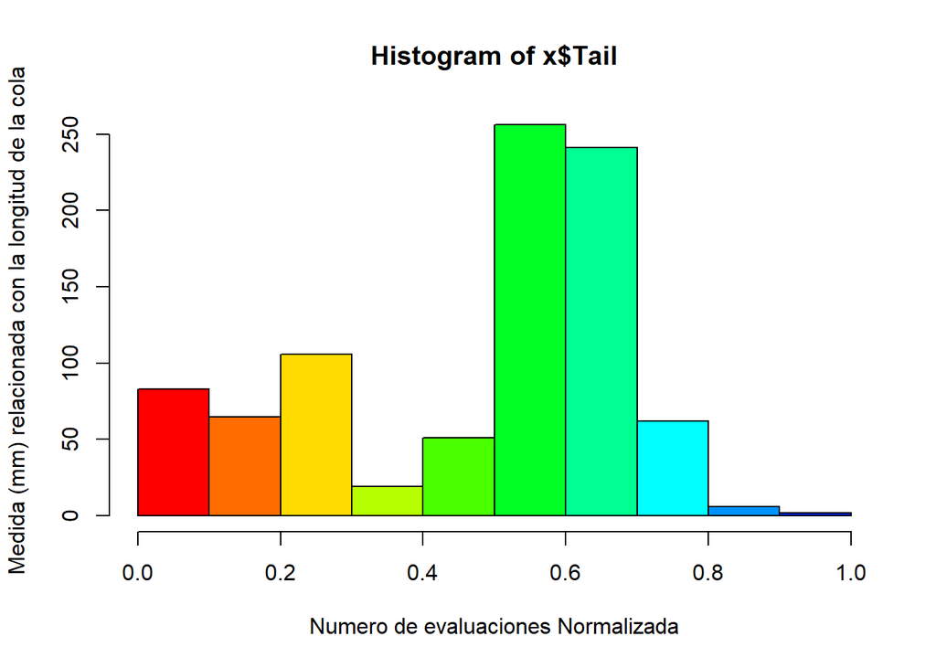

```r
hist(x$Tail,xlab="Numero de evaluaciones Normalizada", col=rainbow(14) ,ylab="Medida (mm) relacionada con la longitud de la cola")
```

Como podemos visualizar en la distrbucion del los variogramas, tenemos que al tratarse de variables de distancia debemos realizarl una estandarización es por lo que se ha realizado un funcion para aplicarla al Dataset

```r
str(x)
```

```
## 'data.frame':    891 obs. of  6 variables:
##  $ Wing        : num  0.785 0.776 0.514 0.379 0.846 ...
##  $ Weight      : num  0.4377 0.4732 0.2097 0.0578 0.5238 ...
##  $ Culmen      : num  0.559 0.592 0.33 0.127 0.65 ...
##  $ Hallux      : num  0.0621 0.0657 0.0422 0.0145 0.0684 ...
##  $ Tail        : num  0.592 0.686 0.598 0.225 0.657 ...
##  $ StandardTail: num  0.383 0.383 0.383 0.383 0.383 ...
```

Probamos varios valores para en contrar el número óptimo de clusters

```r
d <- daisy(x)
resultados <- rep(0, 10)
for (i in c(2,3,4,5,6,7,8,9,10))
{
  fit           <- kmeans(x, i)
  y_cluster     <- fit$cluster
  sk            <- silhouette(y_cluster, d)
  resultados[i] <- mean(sk[,3])
}
```

Grafica de los silueta media para determinacion de el mejor número de cluster

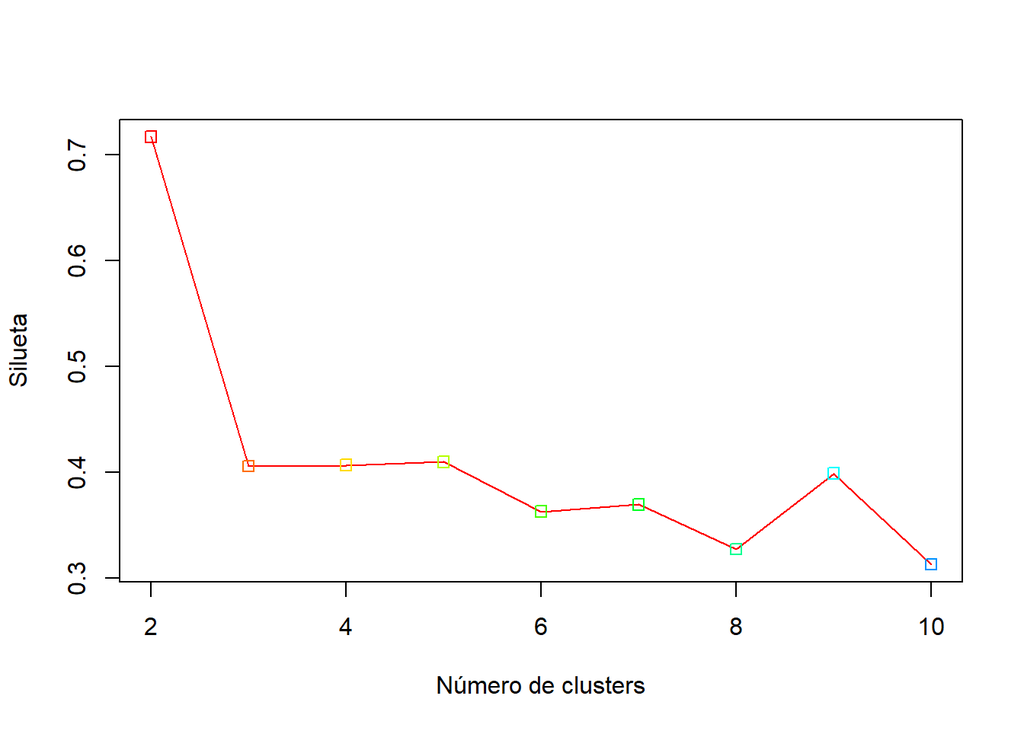

```r
plot(2:10,resultados[2:10],type="o",col=rainbow(14),pch=0,xlab="Número de clusters",ylab="Silueta")
```

Determinación gráfica por el método del codo (elbow)

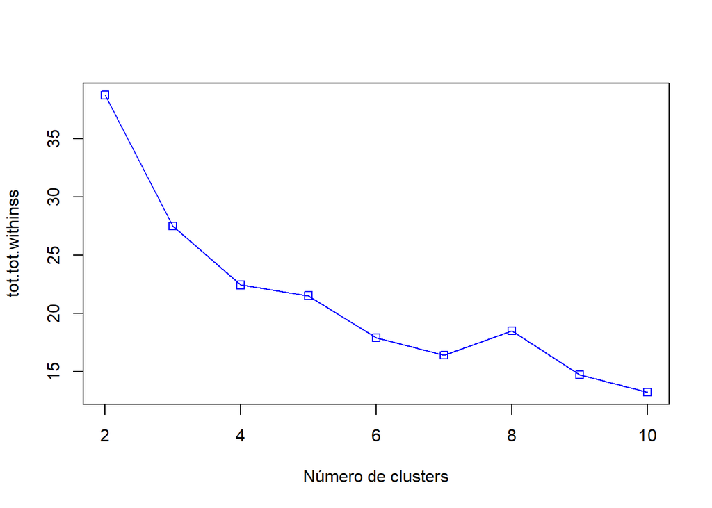

```r
resultados<-rep(0,10)
for(i in c(2,3,4,5,6,7,8,9,10)) {
  fit <- kmeans(x, i)
  resultados[i] <- fit$tot.withinss
  }
plot(2:10,resultados[2:10],type="o",col="blue",pch=0,xlab="Número de clusters",ylab="tot.tot.withinss")
```

Como podemos observar el número optimo nos resulta 4 que es cuando la curva tiende a poseer una curva menos pronunciada (codo)

Determinación k a través de la función kmeansruns del paquete fpc.

```r
fit_ch<-kmeansruns(x,krange =1:10,criterion ="ch")
fit_asw<-kmeansruns(x,krange =1:10,criterion ="asw")
```

```r
fit_ch$bestk
```

```
## [1] 2
```

```r
fit_asw$bestk
```

```
## [1] 2
```

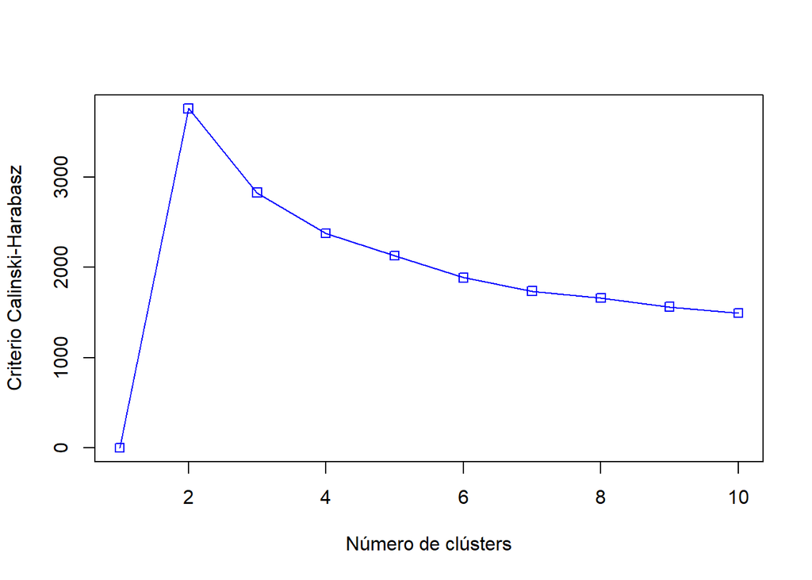

```r
plot(1:10,fit_ch$crit,type="o",col="blue",pch=0,xlab="Número de clústers",ylab="Criterio Calinski-Harabasz")
```

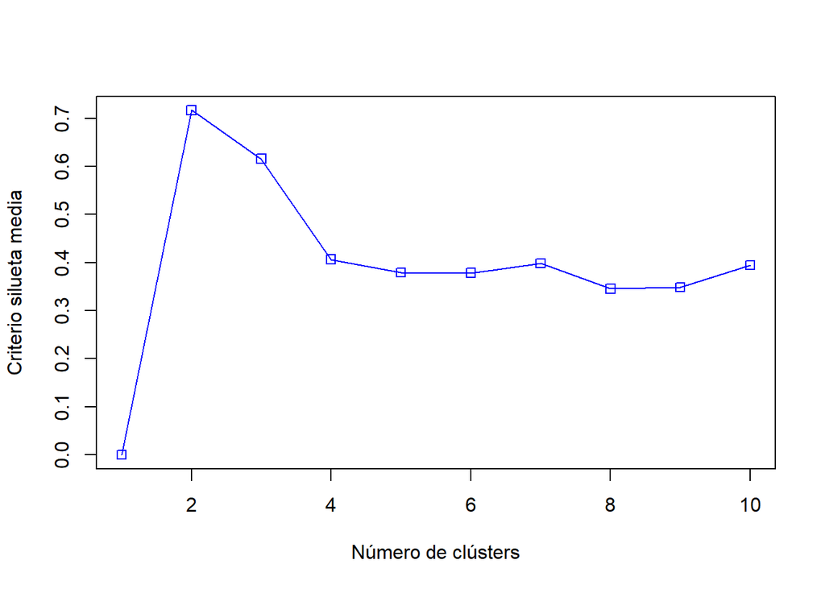

```r
plot(1:10,fit_asw$crit,type="o",col="blue",pch=0,xlab="Número de clústers",ylab="Criterio silueta media")
```

Con el criterio de la silueta media y el de Calinski-Harabasz se obtiene dos clusters en ambos casos. Como en los datos originales tenemos el total de especies podemos afirmar que el numero de cluster correcto es 3. Comprovamos visualmente con el valor real guardado en Species el el dataframe original.

Por motivos de aprendizaje se aplicará diferentes valores de k.

```r
Hawks_2_clusters<-kmeans(x,2)
Hawks_4_clusters<-kmeans(x,4)
Hawks_6_clusters<-kmeans(x,6)
```

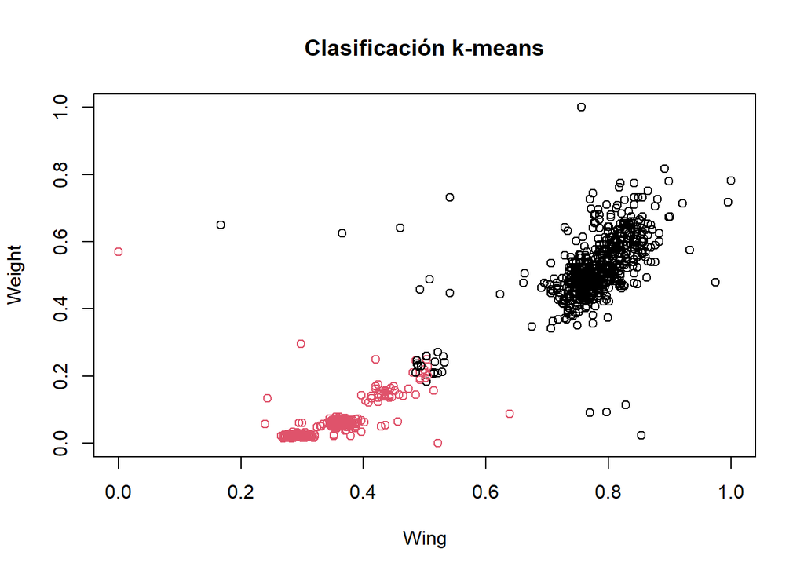

```r
plot(x[c(1,2)],col=Hawks_2_clusters$cluster,main="Clasificación k-means")
```

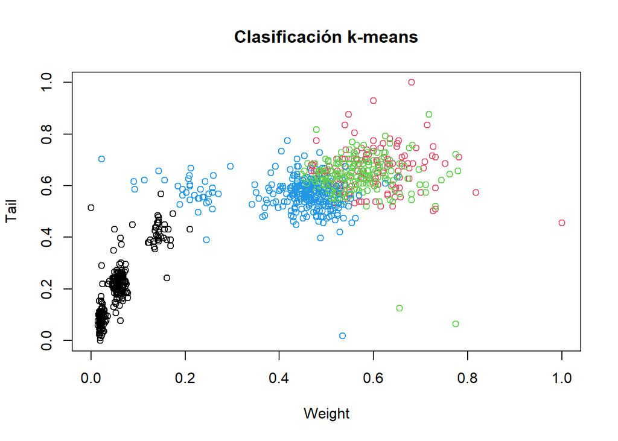

```r
plot(x[c(2,5)],col=Hawks_4_clusters$cluster,main="Clasificación k-means")
```

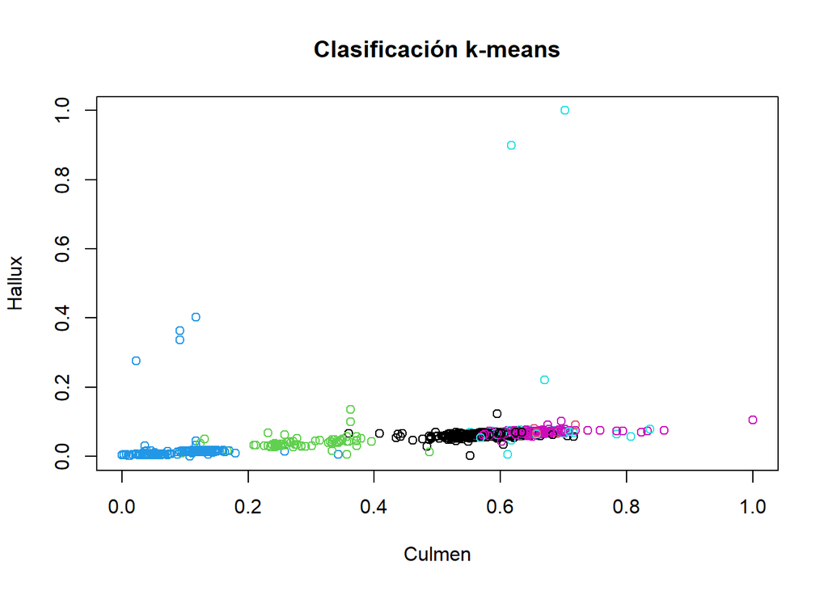

```r
plot(x[c(3,4)],col=Hawks_6_clusters$cluster,main="Clasificación k-means")
```

Como se esplicó anteriormente el valor real de k es 3, por lo cual procedemos a nalizarlo.

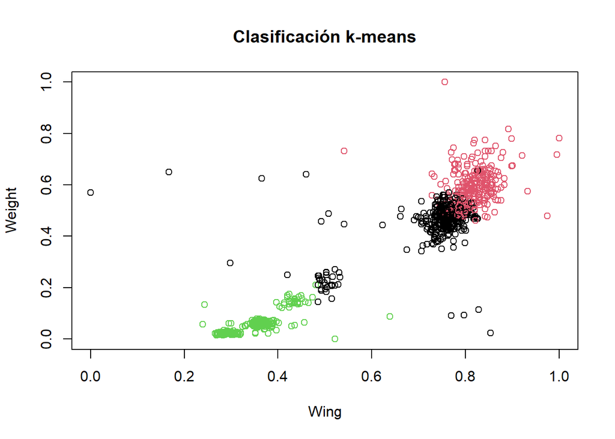

```r
Hawks3clusters<-kmeans(x,3)
# Wing y Weight
plot(x[c(1,2)],col=Hawks3clusters$cluster,main="Clasificación k-means")
```

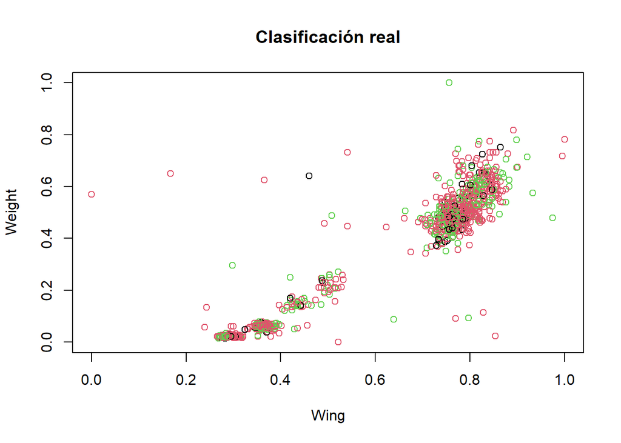

```r
plot(x[c(1,2)],col=as.factor(Hawks$Species),main="Clasificación real")
```

Podemos identificar que Wing y Weight no son buenos indicadores para fiferenciar las tres subespecies debido a que dos de las subespecies están demasiado mezcladas para poder diferenciar nada

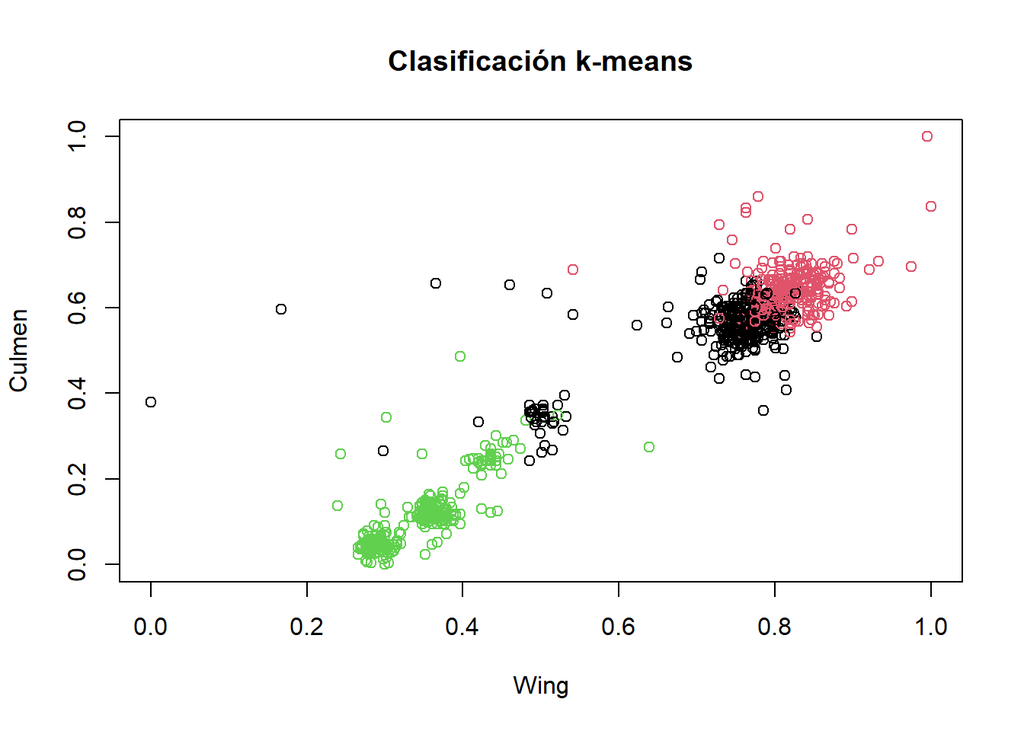

```r
# Wing y Culmen
plot(x[c(1,3)],col=Hawks3clusters$cluster,main="Clasificación k-means")
```

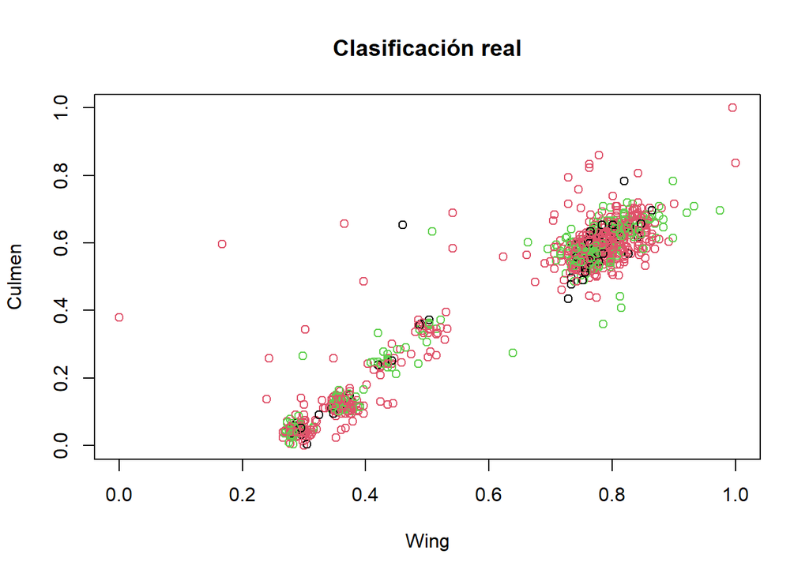

```r
plot(x[c(1,3)],col=as.factor(Hawks$Species),main="Clasificación real")
```

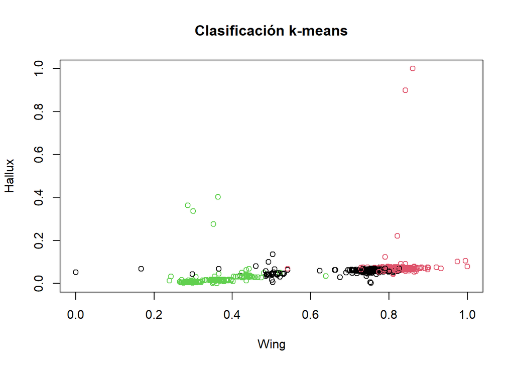

```r
# Wing y Hallux
plot(x[c(1,4)],col=Hawks3clusters$cluster,main="Clasificación k-means")
```

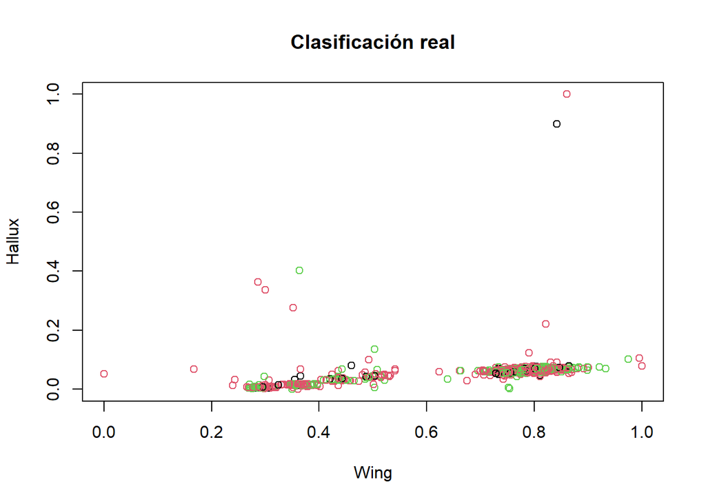

```r
plot(x[c(1,4)],col=as.factor(Hawks$Species),main="Clasificación real")
```

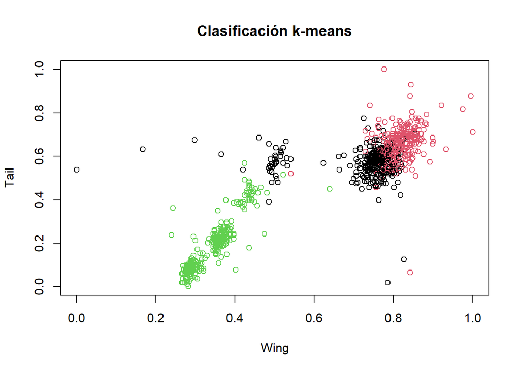

```r
# Wing y Tail
plot(x[c(1,5)],col=Hawks3clusters$cluster,main="Clasificación k-means")
```

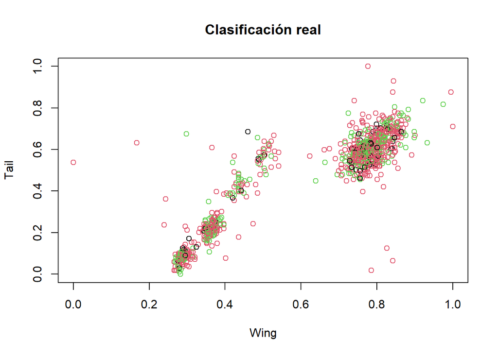

```r
plot(x[c(1,5)],col=as.factor(Hawks$Species),main="Clasificación real")
```

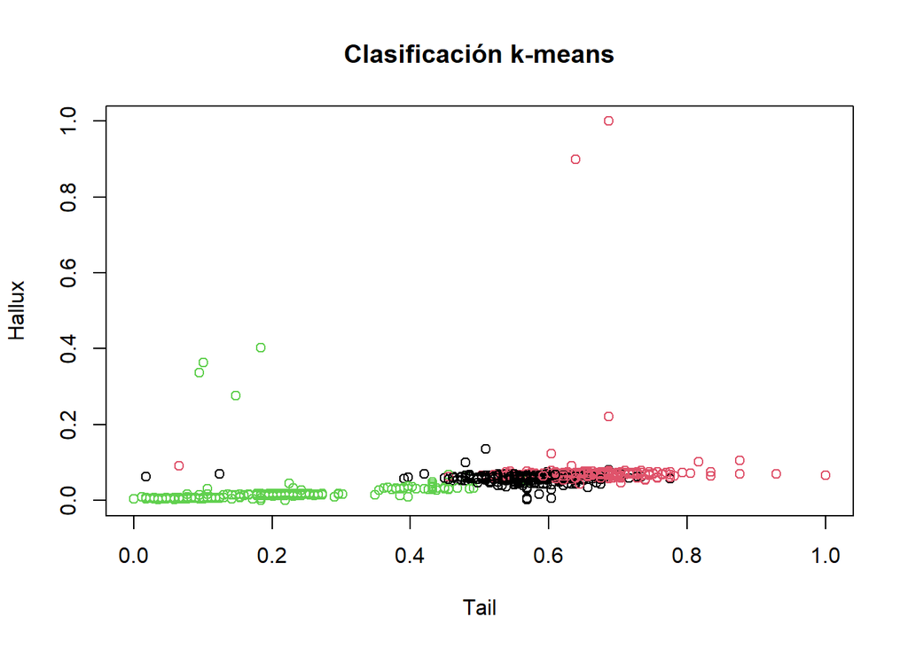

```r
# Hallux y Tail
plot(x[c(5,4)],col=Hawks3clusters$cluster,main="Clasificación k-means")
```

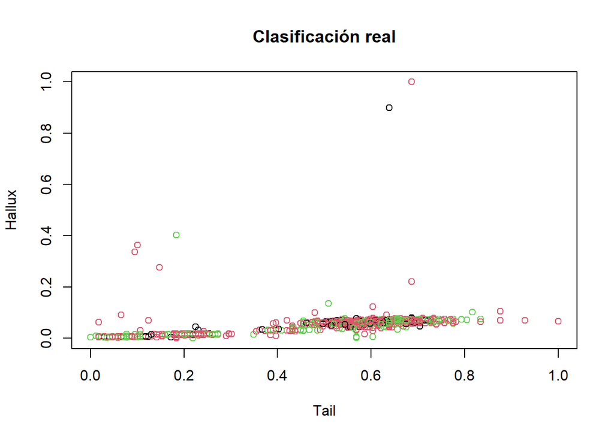

```r
plot(x[c(5,4)],col=as.factor(Hawks$Species),main="Clasificación real")
```

# Ejercicio 2

Con el juego de datos proporcionado realiza un estudio similar al del ejemplo 2

## Métodos basados en densidad: DBSCAN y OPTICS

```r
if(!require('dbscan'))install.packages('dbscan')
library(dbscan)
```

```r
data("Hawks")
```

eliminación de columnas

```r
Hawks <- Hawks[ , !(names(Hawks) %in% c('Tarsus', 'WingPitFat'))] # Eliminación de la columnas diferentes que 'Tarsus', 'WingPitFat'
```

Colocamos la media en StandardTail en sus valores nulos

```r
Hawks$StandardTail[is.na(Hawks$StandardTail)] <- mean(Hawks$StandardTail,na.rm=T)
```

Eliminamos la columna Species para ya que requerimos hacer una clasificación no supervisada

```r
x <- na.omit(Hawks[, c("Wing", "Weight", "Culmen", "Hallux", "Tail", "StandardTail")])
```

Asiganamos 3 zonas diferencidas ya que conocemos que solo existen 3 especies que queremos determinar.

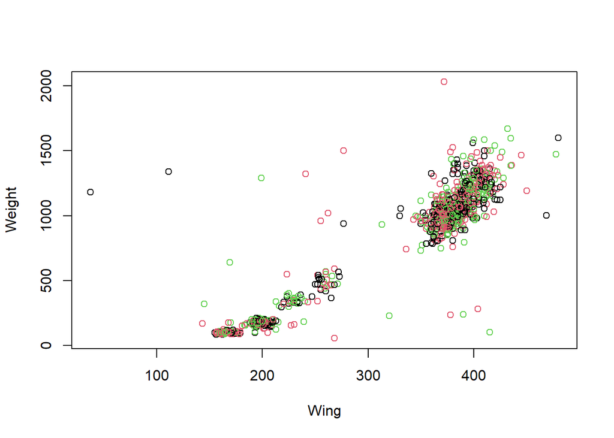

```r
plot(x[c(1,2)],col=rep(1:3,time =100))
```

El aloritmo posibilita que los puntos más cercansos se conviertan en vecinos a través del ordenamiento

```r
### Lanzamos el algoritmo OPTICS dejando el parámetro eps con su valor por defecto y fijando el criterio de vecindad en 10
res <- optics(x[c(1,2)], minPts = 10)
res
```

```
## OPTICS ordering/clustering for 891 objects.
## Parameters: minPts = 10, eps = 531.583483565846, eps_cl = NA, xi = NA
## Available fields: order, reachdist, coredist, predecessor, minPts, eps,
##                   eps_cl, xi
```

```r
### Obtenemos la ordenación de las observaciones o puntos
res$order
```

```
##   [1]   1 830 710 851 656 528 480 464 556 370 287 259 251 540 354 544  17 314
##  [19] 215 223  75 542 456 249 101 254 560 200 728 543 597 452 423 148 274 240
##  [37] 862 757 580 811 599 563 555 278 253 151 134  16 494 531 315 244 884 691
##  [55] 545 510 846 828 426   6 663 717 145 144 130 380 596 816 784 665 632 699
##  [73] 565 773 685 566 754 604 589 501 326 118 114  88  23   2 516 413 855 748
##  [91] 729 473 469 179 108 845 839 197  11 807 762 860 634 467 453 397 286 150
## [109] 113 808 749 585 491 457 375 238 881 874 578 534 414 324 308 262 180 132
## [127] 126  87  74 459 160 111 359 275 273  43 229 410 270 216 742 724 633 492
## [145] 727 446 832 591 573 451 368 284 243 141  45 771 746 650 577 193 185 333
## [163] 539 443 277 188  85  44 755 344 436 355 226 199 175 758 362 154  82  40
## [181] 875 592 129 327 871 796 701 601 424 289  42 876 769 515 490 744 266 178
## [199] 176 173  18  10 417 328  28 500 392 381 174 149 485 233  30 512 703 631
## [217] 613 590 768 655 586 584 550 536 441 393 191  65 680 332 776 766 335 329
## [235] 321 574 142 582 395 779 421 177 172 161  24 651 345 158  33 164 487 146
## [253] 676 615 449 257  97  46 211 194 759 693 518 475 420 357 258 313 131 829
```

[output cut: 35 more lines]

Visualización del algoritmo a través de un diagrama de alcanzabilidad donde los valles representan clusters (cuanto más profundo es el valle, más denso es el cluster), mientras que las cimas indican los puntos que están entre las agrupaciones (estos puntos son cadidatos a ser considerardos outliers)

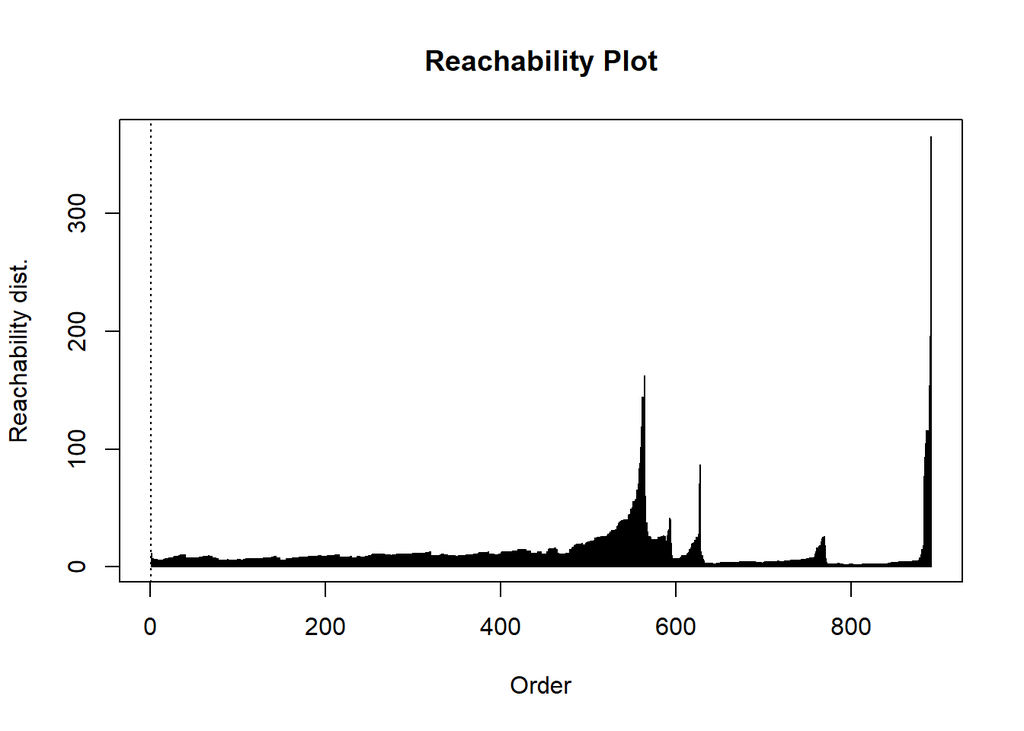

```r
plot(res)
```

Otra repesentacion gráfica de alcanzabilidad donde se puede observar las trazas de las distancias entre puntos cercanos del mismo cluster y entre clusters distintos.

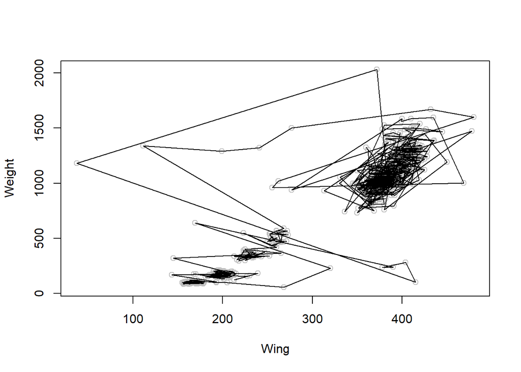

```r
### Dibujo de las trazas que relacionan puntos
plot(x[c(1,2)],col ="grey")
polygon(x[res$order,])
```

```r
### Extracción de un clustering DBSCAN cortando la alcanzabilidad en el valor eps_cl donde eps es el máximo radio de vecindad
res<-extractDBSCAN(res,eps_cl =40)
res
```

```
## OPTICS ordering/clustering for 891 objects.
## Parameters: minPts = 10, eps = 531.583483565846, eps_cl = 40, xi = NA
## The clustering contains 4 cluster(s) and 34 noise points.
##
##   0   1   2   3   4
##  34 541  28  33 255
##
## Available fields: order, reachdist, coredist, predecessor, minPts, eps,
##                   eps_cl, xi, cluster
```

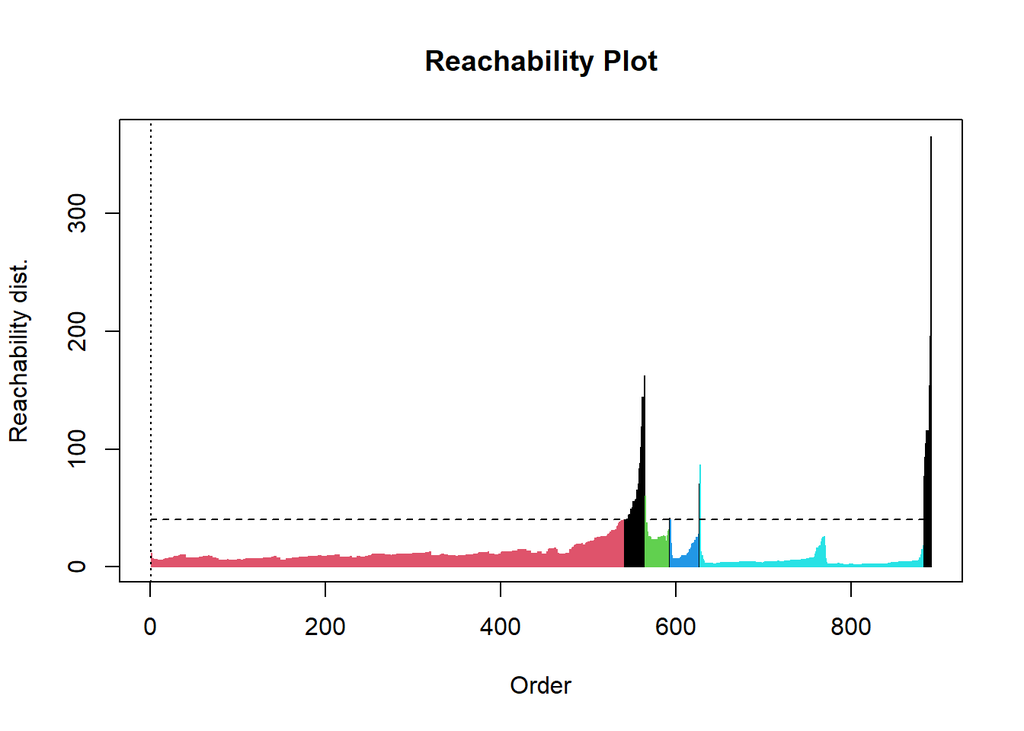

```r
plot(res)
```

Los 4 clusters coloreados y en negro se mantienen los valores outliers.

Seguimos adelante con una representación gráfica que nos muestra los clusters mediante formas convexas.

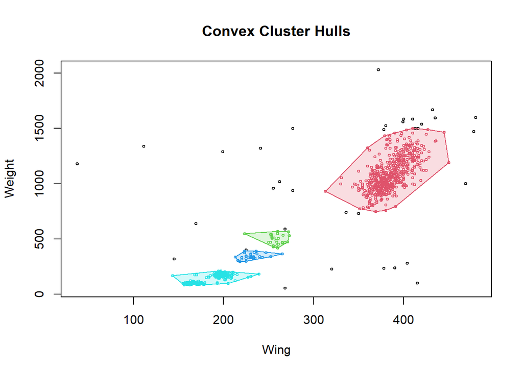

```r
hullplot(x[c(1,2)], res)
```

```r
### Incrementamos el parámetro eps
res<-extractDBSCAN(res,eps_cl =85)
res
```

```
## OPTICS ordering/clustering for 891 objects.
## Parameters: minPts = 10, eps = 531.583483565846, eps_cl = 85, xi = NA
## The clustering contains 3 cluster(s) and 13 noise points.
##
##   0   1   2   3
##  13 558  64 256
##
## Available fields: order, reachdist, coredist, predecessor, minPts, eps,
##                   eps_cl, xi, cluster
```

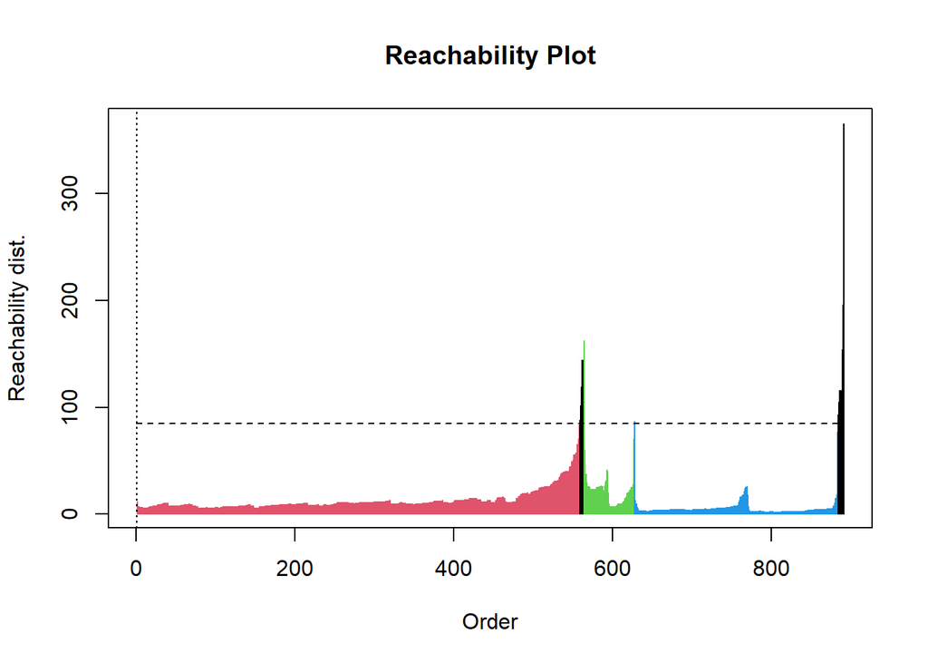

```r
plot(res)
```

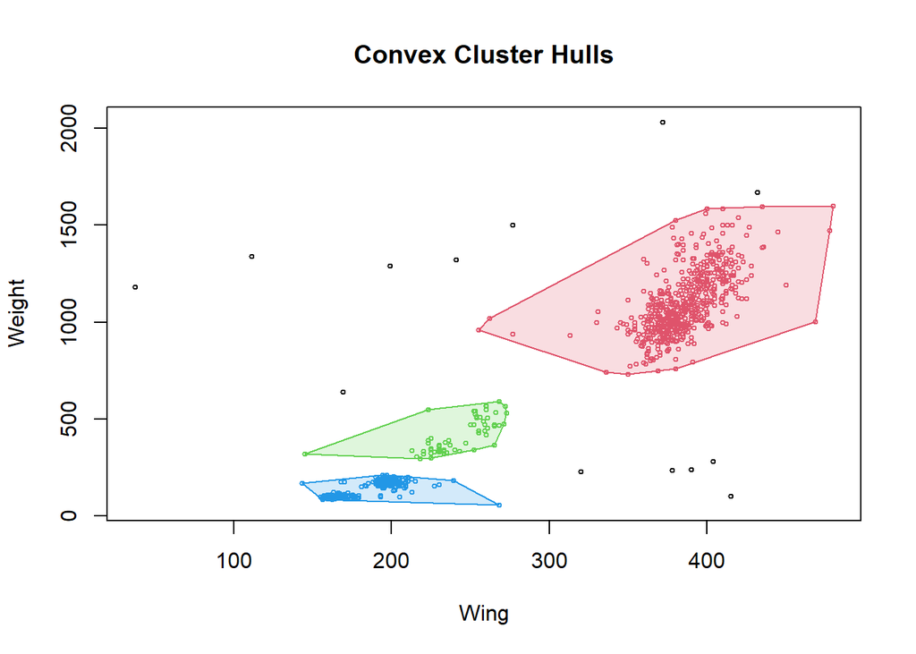

```r
hullplot(x[c(1,2)], res)
```

Variante de la extracción DBSCN anterior. En ella el parámetro xi nos va a servir para clasificar los clusters en función del cambio en la densidad relativa de los mismos.

```r
### Extracción del clustering jerárquico en función de la variación de la densidad por el método xi
res <- extractXi(res, xi = 0.35)
res
```

```
## OPTICS ordering/clustering for 891 objects.
## Parameters: minPts = 10, eps = 531.583483565846, eps_cl = NA, xi = 0.35
## The clustering contains 3 cluster(s) and 1 noise points.
##
## Available fields: order, reachdist, coredist, predecessor, minPts, eps,
##                   eps_cl, xi, cluster, clusters_xi
```

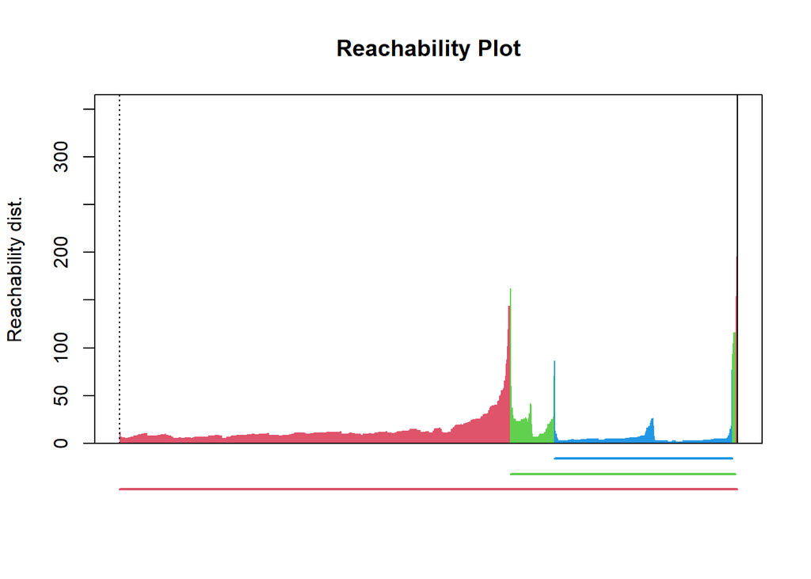

```r
plot(res)
```

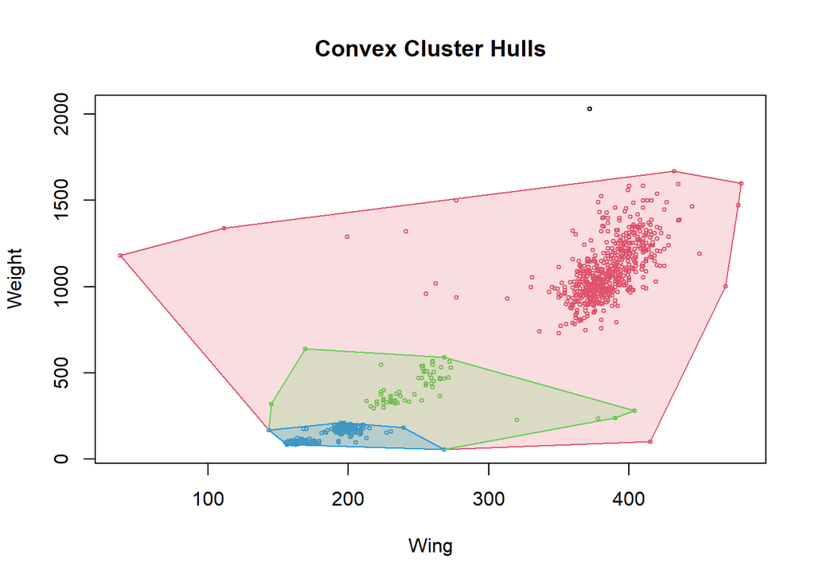

```r
hullplot(x[c(1,2)], res)
```

# Ejercico 3

Realiza una comparativa de los métodos k-means y DBSCAN

Como podemos observar en ambos casos se realizan cluster (agrupaciones) de los elementos más cercanos a nuestra semilla. En el caso de DBSCAN nos brinda la posibilidad de tener figuras no geométricas las que abarquen a datos cuyos valores son extremos identificando las zonas que presentan la más baja densidad,es decir no se encuentran cerca tal como se pudo comprobar en los clusters de K-means donde poseen 3 grupos perfectamente definidos mismos que no correspondían a la Clasificación Real.

Como se pudo observar en las dos últimas la distribución de los datos no es homogénea, ya que tenemos datos muy dispersos a través del plot en ambos casos lo que nos indica que el mejor algoritmo para la identificacion de las Species fue DBSCAN.

Una desventaja que se podría mencionar respecto a DBSCAN se trata que se debió realizar mediante prueba y error para identidicar el parámaetro que mejor se ajuste al máximo radio de vecindad (épsilon) y el mínimo número de puntos en la ε-vecindad de un punto (minPts) además posibilita la cración de clusters sin necesidad de determinar su numero exacto a difencia del K-means en donde necesariamnete debemos otorgar el valor del número de centroides (k).

El presente trabajo posibilita encontrar correlacionar variables para determinar agrupaciones mismas que correspondan a una categoría defeinida, en este caso las especies de alcones. Ya que el objetivo de esta tarea fue plantear algoritmos no supervisados es necesario eliminar la categoría Species, misma que será usadas para comparar los resultados obtenidos a través de los algoritsmos de clustering.